# Final Project

Waheeb Algabri

##### Introduction

In this final exam, we delve into Computational Mathematics by participating in the House Prices: Advanced Regression Techniques competition hosted on Kaggle.com. Through this exam, we aim to showcase our understanding of various mathematical concepts, statistical methods, and their application in real-world datasets. The exam spans across different branches of mathematics including probability theory, descriptive and inferential statistics, linear algebra, calculus-based probability and statistics, and modeling through regression analysis.

##### Installing required Libraries

##### Data

```r
houses <- fread("https://raw.githubusercontent.com/waheeb123/Data-605/main/Final%20Project/house-prices-advanced-regression-techniques/train.csv")

names(houses) <- tolower(gsub(" ", "_", names(houses)))

str(houses)
```

```
## Classes 'data.table' and 'data.frame':   1460 obs. of  81 variables:
##  $ id           : int  1 2 3 4 5 6 7 8 9 10 ...
##  $ mssubclass   : int  60 20 60 70 60 50 20 60 50 190 ...
##  $ mszoning     : chr  "RL" "RL" "RL" "RL" ...
##  $ lotfrontage  : int  65 80 68 60 84 85 75 NA 51 50 ...
##  $ lotarea      : int  8450 9600 11250 9550 14260 14115 10084 10382 6120 7420 ...
##  $ street       : chr  "Pave" "Pave" "Pave" "Pave" ...
##  $ alley        : chr  NA NA NA NA ...
##  $ lotshape     : chr  "Reg" "Reg" "IR1" "IR1" ...
##  $ landcontour  : chr  "Lvl" "Lvl" "Lvl" "Lvl" ...
##  $ utilities    : chr  "AllPub" "AllPub" "AllPub" "AllPub" ...
##  $ lotconfig    : chr  "Inside" "FR2" "Inside" "Corner" ...
##  $ landslope    : chr  "Gtl" "Gtl" "Gtl" "Gtl" ...
##  $ neighborhood : chr  "CollgCr" "Veenker" "CollgCr" "Crawfor" ...
##  $ condition1   : chr  "Norm" "Feedr" "Norm" "Norm" ...
```

[output cut: 68 more lines]

```r
dim(houses)
```

```
## [1] 1460   81
```

```r
kable(head(houses))
```

| id | mssubclass | mszoning | lotfrontage | lotarea | street | alley | lotshape | landcontour | utilities | lotconfig | landslope | neighborhood | condition1 | condition2 | bldgtype | housestyle | overallqual | overallcond | yearbuilt | yearremodadd | roofstyle | roofmatl | exterior1st | exterior2nd | masvnrtype | masvnrarea | exterqual | extercond | foundation | … |
| --- | --- | --- | --- | --- | --- | --- | --- | --- | --- | --- | --- | --- | --- | --- | --- | --- | --- | --- | --- | --- | --- | --- | --- | --- | --- | --- | --- | --- | --- | --- |
| 1 | 60 | RL | 65 | 8450 | Pave | NA | Reg | Lvl | AllPub | Inside | Gtl | CollgCr | Norm | Norm | 1Fam | 2Story | 7 | 5 | 2003 | 2003 | Gable | CompShg | VinylSd | VinylSd | BrkFace | 196 | Gd | TA | PConc | … |
| 2 | 20 | RL | 80 | 9600 | Pave | NA | Reg | Lvl | AllPub | FR2 | Gtl | Veenker | Feedr | Norm | 1Fam | 1Story | 6 | 8 | 1976 | 1976 | Gable | CompShg | MetalSd | MetalSd | None | 0 | TA | TA | CBlock | … |
| 3 | 60 | RL | 68 | 11250 | Pave | NA | IR1 | Lvl | AllPub | Inside | Gtl | CollgCr | Norm | Norm | 1Fam | 2Story | 7 | 5 | 2001 | 2002 | Gable | CompShg | VinylSd | VinylSd | BrkFace | 162 | Gd | TA | PConc | … |
| 4 | 70 | RL | 60 | 9550 | Pave | NA | IR1 | Lvl | AllPub | Corner | Gtl | Crawfor | Norm | Norm | 1Fam | 2Story | 7 | 5 | 1915 | 1970 | Gable | CompShg | Wd Sdng | Wd Shng | None | 0 | TA | TA | BrkTil | … |
| 5 | 60 | RL | 84 | 14260 | Pave | NA | IR1 | Lvl | AllPub | FR2 | Gtl | NoRidge | Norm | Norm | 1Fam | 2Story | 8 | 5 | 2000 | 2000 | Gable | CompShg | VinylSd | VinylSd | BrkFace | 350 | Gd | TA | PConc | … |
| 6 | 50 | RL | 85 | 14115 | Pave | NA | IR1 | Lvl | AllPub | Inside | Gtl | Mitchel | Norm | Norm | 1Fam | 1.5Fin | 5 | 5 | 1993 | 1995 | Gable | CompShg | VinylSd | VinylSd | None | 0 | TA | TA | Wood | … |

#### Missing Values and NA’s

Handling missing values in the berginning to perform analysis smoothly later on. Creating a dataframe for columns of the dataframe houses to remove NA’swith required values(variables). Table out the values connecting each other to analyze NA’s and remove or replace with required data. In our dataset garage condition, garage type, garage condition are interlinked, creating pairs to check this and handle the missing values.

```r
df_na<- data.frame(colSums(is.na(houses)))
names(df_na)<- c( "na")


kable(table(houses$poolqc,houses$poolarea, useNA = 'ifany'))
```

|  | 0 | 480 | 512 | 519 | 555 | 576 | 648 | 738 |
| --- | --- | --- | --- | --- | --- | --- | --- | --- |
| Ex | 0 | 0 | 1 | 0 | 1 | 0 | 0 | 0 |
| Fa | 0 | 0 | 0 | 1 | 0 | 0 | 1 | 0 |
| Gd | 0 | 1 | 0 | 0 | 0 | 1 | 0 | 1 |
| NA | 1453 | 0 | 0 | 0 | 0 | 0 | 0 | 0 |

```r
## 1,453 NA's with poolarea 0. assuming there is no pool, replace with "None"
houses$poolqc[is.na(houses$poolqc)]<- "None"

## Using similar technique for fire places
table(houses$fireplacequ,houses$fireplaces,useNA = 'ifany')
```

```
##
##          0   1   2   3
##   Ex     0  19   4   1
##   Fa     0  28   4   1
##   Gd     0 324  54   2
##   Po     0  20   0   0
##   TA     0 259  53   1
##   <NA> 690   0   0   0
```

```r
houses$fireplacequ[is.na(houses$fireplacequ)] <- "None"




## missing values for allcolumns related to garage, assuming no garage at all
#table(houses$garagetype,houses$garageyrblt,useNA = 'ifany')


houses$garagetype[is.na(houses$garagetype)] <- "None"
houses$garageyrblt[is.na(houses$garageyrblt)] <- ""
houses$garagecond[is.na(houses$garagecond)] <- "None"
houses$garagefinish[is.na(houses$garagefinish)] <- "None"
houses$garagequal[is.na(houses$garagequal)] <- "None"



## another category
table(is.na(houses$masvnrarea),is.na(houses$masvnrtype))
```

```
##
##         FALSE TRUE
##   FALSE  1452    0
##   TRUE      0    8
```

```r
houses$masvnrtype[is.na(houses$masvnrtype)] <- "None"
houses$masvnrarea[is.na(houses$masvnrarea)] <- 0


##for basement

table(houses$bsmtfintype1,houses$bsmtfintype2, useNA = 'ifany')
```

```
##
##        ALQ BLQ GLQ LwQ Rec Unf <NA>
##   ALQ    0  15   2  15  22 166    0
##   BLQ    2   1   5  13  15 112    0
##   GLQ    4   2   0  10   9 392    1
##   LwQ    9   4   7   0   8  46    0
##   Rec    4  11   0   8   0 110    0
##   Unf    0   0   0   0   0 430    0
##   <NA>   0   0   0   0   0   0   37
```

```r
houses$bsmtfintype1[is.na(houses$bsmtfintype1)] <- "None"
houses$bsmtfintype2[is.na(houses$bsmtfintype2)] <- "None"

table(houses$bsmtqual,houses$bsmtcond, useNA = 'ifany')
```

```
##
##         Fa  Gd  Po  TA <NA>
##   Ex     0  11   0 110    0
##   Fa     8   0   2  25    0
##   Gd     2  36   0 580    0
##   TA    35  18   0 596    0
##   <NA>   0   0   0   0   37
```

```r
houses$bsmtqual[is.na(houses$bsmtqual)] <- "None"
houses$bsmtcond[is.na(houses$bsmtcond)] <- "None"
houses$bsmtexposure[is.na(houses$bsmtexposure)] <- "None"
## we can replace basement exposure  with "No" as it is included in the values, we assume it is different than ##having a basement with no exposure or no basement at all



### misc. columns
houses$miscfeature[is.na(houses$miscfeature)] <- "None"
houses$fence[is.na(houses$fence)] <- "None"
houses$alley[is.na(houses$alley)] <- "None"
houses$lotfrontage[is.na(houses$lotfrontage)] <- 0
houses$electrical[is.na(houses$electrical)] <- "None"




colSums(is.na(houses))
```

```
##            id    mssubclass      mszoning   lotfrontage       lotarea
##             0             0             0             0             0
##        street         alley      lotshape   landcontour     utilities
##             0             0             0             0             0
##     lotconfig     landslope  neighborhood    condition1    condition2
##             0             0             0             0             0
##      bldgtype    housestyle   overallqual   overallcond     yearbuilt
##             0             0             0             0             0
##  yearremodadd     roofstyle      roofmatl   exterior1st   exterior2nd
##             0             0             0             0             0
##    masvnrtype    masvnrarea     exterqual     extercond    foundation
##             0             0             0             0             0
##      bsmtqual      bsmtcond  bsmtexposure  bsmtfintype1    bsmtfinsf1
##             0             0             0             0             0
##  bsmtfintype2    bsmtfinsf2     bsmtunfsf   totalbsmtsf       heating
##             0             0             0             0             0
##     heatingqc    centralair    electrical      1stflrsf      2ndflrsf
##             0             0             0             0             0
##  lowqualfinsf     grlivarea  bsmtfullbath  bsmthalfbath      fullbath
##             0             0             0             0             0
##      halfbath  bedroomabvgr  kitchenabvgr   kitchenqual  totrmsabvgrd
##             0             0             0             0             0
##    functional    fireplaces   fireplacequ    garagetype   garageyrblt
##             0             0             0             0             0
##  garagefinish    garagecars    garagearea    garagequal    garagecond
##             0             0             0             0             0
##    paveddrive    wooddecksf   openporchsf enclosedporch     3ssnporch
##             0             0             0             0             0
##   screenporch      poolarea        poolqc         fence   miscfeature
##             0             0             0             0             0
##       miscval        mosold        yrsold      saletype salecondition
##             0             0             0             0             0
##     saleprice
##             0
```

```r
## no misiing values, we can move forward with the analysis.
```

Another required check is to find unique levels of categorical variables.Categories are incorrectly entered as lower case or first letter is capitalized. e.g. column misc feature has the categoies

“None” “Shed” “Gar2” “Othr” “TenC”. We can perform a check at the variables if the data is correct. “Othr” “othr” might corresponds to same category. Random check was performed on few categorical variables. Based on the variables required for analysis, this can be performed on them.

```r
## performing a random check at cat. variables.

unique(houses$extercond)
```

```
## [1] "TA" "Gd" "Fa" "Po" "Ex"
```

```r
unique(houses$extercond)
```

```
## [1] "TA" "Gd" "Fa" "Po" "Ex"
```

```r
unique(houses$miscval)
```

```
##  [1]     0   700   350   500   400   480   450 15500  1200   800  2000   600
## [13]  3500  1300    54   620   560  1400  8300  1150  2500
```

```r
unique(houses$street)
```

```
## [1] "Pave" "Grvl"
```

##### Selecting Variables for Probability

Pick one of the quanititative independent variables from the training data set (train.csv) , and define that variable as X. Make sure this variable is skewed to the right! Pick the dependent variable and define it as Y.

Plotting the variables.

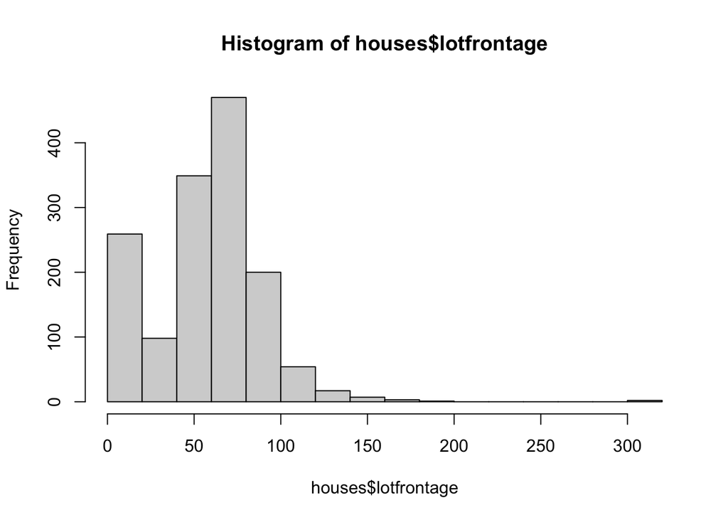

```r
X<- hist (houses$lotfrontage)
```

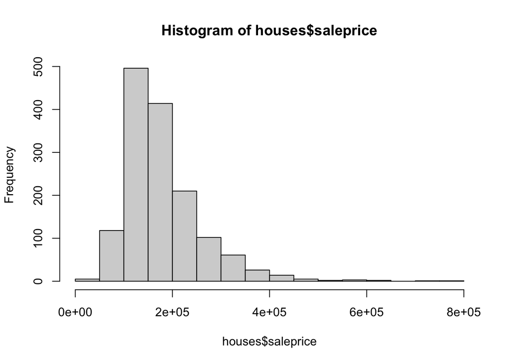

```r
Y<- hist (houses$saleprice)
```

##### Probability

Calculate as a minimum the below probabilities a through c. Assume the small letter “x” is estimated as the 3d quartile of the X variable, and the small letter “y” is estimated as the 2d quartile of the Y variable. Interpret the meaning of all probabilities. In addition, make a table of counts as shown below.

```r
# Extract data
X <- houses$lotfrontage
Y <- houses$saleprice

# Compute quartiles
## Third quartile of X
x <- quantile(X, 0.75, na.rm = TRUE)

## Second quartile of Y
y <- quantile(Y, 0.50, na.rm = TRUE)
```

```r
# Interpretation of probabilities
# a. P(X>x | Y>y)
prob_a <- sum(X > x & Y > y) / sum(Y > y)

# b. P(X>x, Y>y)
prob_b <- sum(X > x & Y > y) / length(X) # Assuming total number of observations for X and Y are the same

# c. P(X<x | Y>y)
prob_c <- sum(X < x & Y > y) / sum(Y > y)

# Create a table of counts
table_X <- cut(X, breaks = c(-Inf, x, Inf), labels = c("<=3d quartile", ">3d quartile"))
table_Y <- cut(Y, breaks = c(-Inf, y, Inf), labels = c("<=2d quartile", ">2d quartile"))
table_counts <- table(table_X, table_Y)

# Add totals to the table
table_counts_with_totals <- addmargins(table_counts)

# Display results
print("Probability a:")
```

```
## [1] "Probability a:"
```

```r
print(kable(prob_a))
```

```
##
##
## |         x|
## |---------:|
## | 0.3337912|
```

```r
print("Probability b:")
```

```
## [1] "Probability b:"
```

```r
print(kable(prob_b))
```

```
##
##
## |         x|
## |---------:|
## | 0.1664384|
```

```r
print("Probability c:")
```

```
## [1] "Probability c:"
```

```r
print(kable(prob_c))
```

```
##
##
## |         x|
## |---------:|
## | 0.6510989|
```

```r
print("Table of counts:")
```

```
## [1] "Table of counts:"
```

```r
print(kable(table_counts_with_totals))
```

```
##
##
## |              | <=2d quartile| >2d quartile|  Sum|
## |:-------------|-------------:|------------:|----:|
## |<=3d quartile |           622|          485| 1107|
## |>3d quartile  |           110|          243|  353|
## |Sum           |           732|          728| 1460|
```

**a. P(X>x | Y>y)**

**b. P(X>x, Y>y)**

The probability indicates the likelihood of both lot frontage (X) and sale price (Y) exceeding their respective quartile values (x) and (y). It’s computed by dividing the count of observations where both X and Y exceed their quartile values (243) by the total count of observations (1460).

**c. P(X<x | Y>y)**

**Does splitting the training data in this fashion make them independent? Let A be the new variable counting those observations above the 3d quartile for X, and let B be the new variable counting those observations above the 2d quartile for Y. Does P(A|B)=P(A)P(B)? Check mathematically, and then evaluate by running a Chi Square test for association.**

```r
# Calculate total count of observations
total_count <- nrow(houses)

# Calculate counts for A (observations above the third quartile for X) and B (observations above the second quartile for Y)
count_A <- sum(X > x)  # Count of observations above the third quartile for X
count_B <- sum(Y > y)  # Count of observations above the second quartile for Y

# Calculate probabilities
prob_A <- count_A / total_count
prob_B <- count_B / total_count

# Extract counts for A and B
table_A <- table_X == ">3d quartile"
table_B <- table_Y == ">2d quartile"

# Calculate count of observations in A and B
count_A_and_B <- sum(table_A & table_B)

# Calculate probability of A intersection B
prob_A_and_B <- count_A_and_B / total_count

# Calculate conditional probability P(A|B)
prob_A_given_B <- prob_A_and_B / prob_B

# Check if P(A|B) = P(A) * P(B)
is_independent <- prob_A_given_B == (prob_A * prob_B)

# Chi-square test for association
chisq_test <- chisq.test(table_counts)
```

```r
# Display results
cat("Probability of observations above the third quartile for X (A):", prob_A, "\n")
```

```
## Probability of observations above the third quartile for X (A): 0.2417808
```

```r
cat("Probability of observations above the second quartile for Y (B):", prob_B, "\n")
```

```
## Probability of observations above the second quartile for Y (B): 0.4986301
```

```r
cat("Probability of observations in both A and B (A ∩ B):", prob_A_and_B, "\n")
```

```
## Probability of observations in both A and B (A ∩ B): 0.1664384
```

```r
cat("Conditional probability P(A|B):", prob_A_given_B, "\n")
```

```
## Conditional probability P(A|B): 0.3337912
```

```r
cat("Is A independent of B (P(A|B) = P(A) * P(B)):", is_independent, "\n\n")
```

```
## Is A independent of B (P(A|B) = P(A) * P(B)): FALSE
```

```r
# Chi-square test result
cat("Chi-square test for association:\n")
```

```
## Chi-square test for association:
```

```r
print(chisq_test)
```

```
##
##  Pearson's Chi-squared test with Yates' continuity correction
##
## data:  table_counts
## X-squared = 66.058, df = 1, p-value = 4.38e-16
```

The Chi-square test indicates a significant association between the variables A and B, rejecting the hypothesis of independence.

##### Descriptive and Inferential Statistics.

Provide univariate descriptive statistics and appropriate plots for the training data set. Provide a scatterplot of X and Y. Provide a 95% CI for the difference in the mean of the variables. Derive a correlation matrix for two of the quantitative variables you selected. Test the hypothesis that the correlation between these variables is 0 and provide a 99% confidence interval. Discuss the meaning of your analysis.

```r
# Univariate Descriptive Statistics
summary(houses)
```

```
##        id           mssubclass      mszoning          lotfrontage
##  Min.   :   1.0   Min.   : 20.0   Length:1460        Min.   :  0.00
##  1st Qu.: 365.8   1st Qu.: 20.0   Class :character   1st Qu.: 42.00
##  Median : 730.5   Median : 50.0   Mode  :character   Median : 63.00
##  Mean   : 730.5   Mean   : 56.9                      Mean   : 57.62
##  3rd Qu.:1095.2   3rd Qu.: 70.0                      3rd Qu.: 79.00
##  Max.   :1460.0   Max.   :190.0                      Max.   :313.00
##     lotarea          street             alley             lotshape
##  Min.   :  1300   Length:1460        Length:1460        Length:1460
##  1st Qu.:  7554   Class :character   Class :character   Class :character
##  Median :  9478   Mode  :character   Mode  :character   Mode  :character
##  Mean   : 10517
##  3rd Qu.: 11602
##  Max.   :215245
##  landcontour         utilities          lotconfig          landslope
##  Length:1460        Length:1460        Length:1460        Length:1460
##  Class :character   Class :character   Class :character   Class :character
##  Mode  :character   Mode  :character   Mode  :character   Mode  :character
##
##
##
##  neighborhood        condition1         condition2          bldgtype
##  Length:1460        Length:1460        Length:1460        Length:1460
##  Class :character   Class :character   Class :character   Class :character
##  Mode  :character   Mode  :character   Mode  :character   Mode  :character
##
##
##
##   housestyle         overallqual      overallcond      yearbuilt
##  Length:1460        Min.   : 1.000   Min.   :1.000   Min.   :1872
##  Class :character   1st Qu.: 5.000   1st Qu.:5.000   1st Qu.:1954
##  Mode  :character   Median : 6.000   Median :5.000   Median :1973
##                     Mean   : 6.099   Mean   :5.575   Mean   :1971
##                     3rd Qu.: 7.000   3rd Qu.:6.000   3rd Qu.:2000
##                     Max.   :10.000   Max.   :9.000   Max.   :2010
##   yearremodadd   roofstyle           roofmatl         exterior1st
##  Min.   :1950   Length:1460        Length:1460        Length:1460
##  1st Qu.:1967   Class :character   Class :character   Class :character
##  Median :1994   Mode  :character   Mode  :character   Mode  :character
##  Mean   :1985
```

[output cut: 92 more lines]

```
##                                                           Max.   :15500.00
##      mosold           yrsold       saletype         salecondition
##  Min.   : 1.000   Min.   :2006   Length:1460        Length:1460
##  1st Qu.: 5.000   1st Qu.:2007   Class :character   Class :character
##  Median : 6.000   Median :2008   Mode  :character   Mode  :character
##  Mean   : 6.322   Mean   :2008
##  3rd Qu.: 8.000   3rd Qu.:2009
##  Max.   :12.000   Max.   :2010
##    saleprice
##  Min.   : 34900
##  1st Qu.:129975
##  Median :163000
##  Mean   :180921
##  3rd Qu.:214000
##  Max.   :755000
```

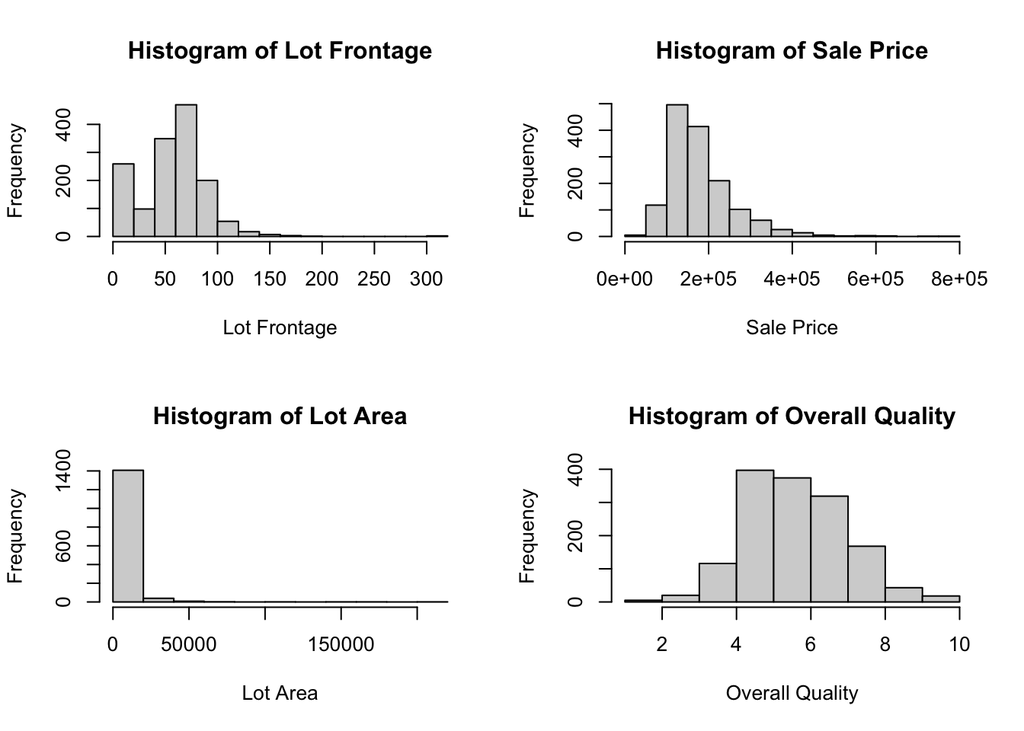

```r
# Plotting histograms for all quantitative variables
par(mfrow = c(2, 2)) # Setting up the layout for multiple plots
hist(houses$lotfrontage, main = "Histogram of Lot Frontage", xlab = "Lot Frontage")
hist(houses$saleprice, main = "Histogram of Sale Price", xlab = "Sale Price")
hist(houses$lotarea, main = "Histogram of Lot Area", xlab = "Lot Area")
hist(houses$overallqual, main = "Histogram of Overall Quality", xlab = "Overall Quality")
```

```r
# Scatterplot of X (lotfrontage) and Y (saleprice)
plot(houses$lotfrontage, houses$saleprice, xlab = "Lot Frontage", ylab = "Sale Price", main = "Scatterplot of Lot Frontage vs. Sale Price")

# 95% Confidence Interval for the Difference in Means
t.test(houses$lotfrontage, houses$saleprice, conf.level = 0.95)
```

```
##
##  Welch Two Sample t-test
##
## data:  houses$lotfrontage and houses$saleprice
## t = -86.991, df = 1459, p-value < 2.2e-16
## alternative hypothesis: true difference in means is not equal to 0
## 95 percent confidence interval:
##  -184941.9 -176785.2
## sample estimates:
##    mean of x    mean of y
##     57.62329 180921.19589
```

```r
# Correlation Matrix
correlation_matrix <- cor(houses[, c("lotfrontage", "saleprice")])

# Test for correlation
correlation_test <- cor.test(houses$lotfrontage, houses$saleprice)

# Confidence Interval for Correlation
correlation_ci <- cor.test(houses$lotfrontage, houses$saleprice, conf.level = 0.99)

# Display results
print("Correlation Matrix:")
```

```
## [1] "Correlation Matrix:"
```

```r
print(correlation_matrix)
```

```
##             lotfrontage saleprice
## lotfrontage   1.0000000 0.2096239
## saleprice     0.2096239 1.0000000
```

```r
print("Test for Correlation:")
```

```
## [1] "Test for Correlation:"
```

```r
print(correlation_test)
```

```
##
##  Pearson's product-moment correlation
##
## data:  houses$lotfrontage and houses$saleprice
## t = 8.1861, df = 1458, p-value = 5.824e-16
## alternative hypothesis: true correlation is not equal to 0
## 95 percent confidence interval:
##  0.1600428 0.2581501
## sample estimates:
##       cor
## 0.2096239
```

```r
print("Confidence Interval for Correlation:")
```

```
## [1] "Confidence Interval for Correlation:"
```

```r
print(correlation_ci)
```

```
##
##  Pearson's product-moment correlation
##
## data:  houses$lotfrontage and houses$saleprice
## t = 8.1861, df = 1458, p-value = 5.824e-16
## alternative hypothesis: true correlation is not equal to 0
## 99 percent confidence interval:
##  0.1442822 0.2731456
## sample estimates:
##       cor
## 0.2096239
```

[figure not shown]

95% CI for Difference in Means: Difference in means between Lot Frontage and Sale Price estimated between -$184,941.9 and -$176,785.2. Correlation: Weak positive correlation (r = 0.21) between Lot Frontage and Sale Price, statistically significant (p < 0.05).

##### Linear Algebra and Correlation.

Invert your correlation matrix. (This is known as the precision matrix and contains variance inflation factors on the diagonal.) Multiply the correlation matrix by the precision matrix, and then multiply the precision matrix by the correlation matrix. Conduct principle components analysis (research this!) and interpret. Discuss.

```r
# Invert the correlation matrix (calculate the precision matrix)
precision_matrix <- solve(correlation_matrix)

# Multiply the correlation matrix by the precision matrix
correlation_precision <- correlation_matrix %*% precision_matrix

# Multiply the precision matrix by the correlation matrix
precision_correlation <- precision_matrix %*% correlation_matrix

# Principal Component Analysis (PCA)
pca_result <- prcomp(houses[, c("lotfrontage", "saleprice")], scale. = TRUE)

# Summary of PCA
summary(pca_result)
```

```
## Importance of components:
##                           PC1    PC2
## Standard deviation     1.0998 0.8890
## Proportion of Variance 0.6048 0.3952
## Cumulative Proportion  0.6048 1.0000
```

The PCA results show that the first principal component (PC1) explains 60.48% of the total variance, while the second principal component (PC2) explains 39.52%. Together, these two components capture all the variance in the dataset, with PC1 being more influential in explaining the variability compared to PC2.

##### Calculus-Based Probability & Statistics.

Many times, it makes sense to fit a closed form distribution to data. For your variable that is skewed to the right, shift it so that the minimum value is above zero. Then load the MASS package and run fitdistr to fit an exponential probability density function. (See https://stat.ethz.ch/R-manual/R-devel/library/MASS/html/fitdistr.html ). Find the optimal value of l for this distribution, and then take 1000 samples from this exponential distribution using this value (e.g., rexp(1000, λ)). Plot a histogram and compare it with a histogram of your original variable. Using the exponential pdf, find the 5th and 95th percentiles using the cumulative distribution function (CDF). Also generate a 95% confidence interval from the empirical data, assuming normality. Finally, provide the empirical 5th percentile and 95th percentile of the data. Discuss.

```r
# Shift the data so that the minimum value is above zero
shifted_data <- houses$lotarea - min(houses$lotarea) + 1

# Load the MASS package
library(MASS)

# Fit exponential distribution using fitdistr
fit_exponential <- fitdistr(shifted_data, "exponential")

# Get the optimal value of lambda
optimal_lambda <- fit_exponential$estimate

# Generate 1000 samples from the exponential distribution
samples <- rexp(1000, rate = optimal_lambda)
```

```r
# Summary of the fitted exponential distribution
print("Summary of the fitted exponential distribution:")
```

```
## [1] "Summary of the fitted exponential distribution:"
```

```r
print(fit_exponential)
```

```
##        rate
##   1.084854e-04
##  (2.839193e-06)
```

```r
# Print the optimal value of lambda
cat("Optimal value of lambda:", optimal_lambda, "\n")
```

```
## Optimal value of lambda: 0.0001084854
```

```r
# Summary statistics of the generated samples
summary(samples)
```

```
##     Min.  1st Qu.   Median     Mean  3rd Qu.     Max.
##     5.19  2478.22  6046.69  9235.46 12769.44 79824.49
```

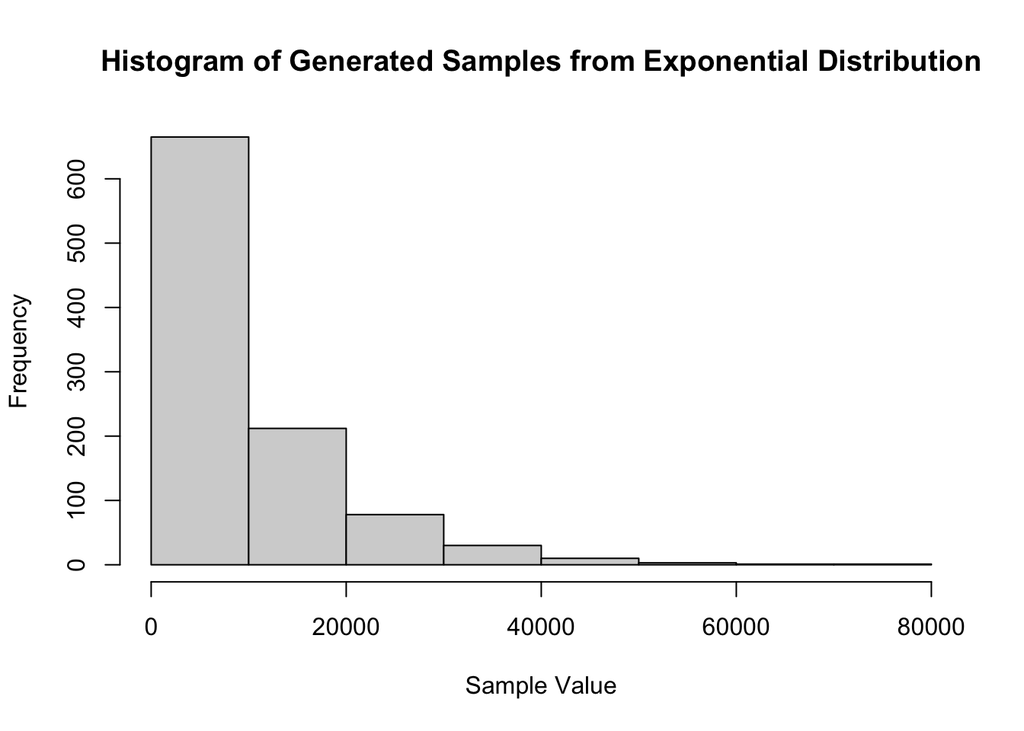

```r
# Visualize the generated samples
hist(samples, main = "Histogram of Generated Samples from Exponential Distribution", xlab = "Sample Value", ylab = "Frequency")
```

```r
# Calculate the 5th and 95th percentiles using the CDF of the fitted exponential distribution
percentile_5 <- qexp(0.05, rate = optimal_lambda)
percentile_95 <- qexp(0.95, rate = optimal_lambda)

# Generate a 95% confidence interval from the empirical data assuming normality
mean_empirical <- mean(shifted_data)
sd_empirical <- sd(shifted_data)
n <- length(shifted_data)
margin_of_error <- qt(0.975, df = n-1) * sd_empirical / sqrt(n)
confidence_interval <- c(mean_empirical - margin_of_error, mean_empirical + margin_of_error)

# Provide the empirical 5th and 95th percentiles of the data
empirical_percentile_5 <- quantile(shifted_data, 0.05)
empirical_percentile_95 <- quantile(shifted_data, 0.95)

# Print the results
cat("5th Percentile using CDF:", percentile_5, "\n")
```

```
## 5th Percentile using CDF: 472.8128
```

```r
cat("95th Percentile using CDF:", percentile_95, "\n")
```

```
## 95th Percentile using CDF: 27614.15
```

```r
cat("95% Confidence Interval from Empirical Data (Normality Assumption):", confidence_interval, "\n")
```

```
## 95% Confidence Interval from Empirical Data (Normality Assumption): 8705.418 9730.238
```

```r
cat("Empirical 5th Percentile:", empirical_percentile_5, "\n")
```

```
## Empirical 5th Percentile: 2012.7
```

```r
cat("Empirical 95th Percentile:", empirical_percentile_95, "\n")
```

```
## Empirical 95th Percentile: 16102.15
```

These values offer a compact overview of the distribution characteristics and provide key insights into the dataset’s variability and central tendency.

##### Modeling.

Build some type of regression model and submit your model to the competition board. Provide your complete model summary and results with analysis. Report your Kaggle.com user name and score.

**Simple linear regression**

```r
# Simple linear regression model of SalePrice by GrLivArea, for later comparison to our multi-linear regression model
train.lm <- lm(Y ~ X, data=houses)

# Get summary of our model
summary(train.lm)
```

```
##
## Call:
## lm(formula = Y ~ X, data = houses)
##
## Residuals:
##     Min      1Q  Median      3Q     Max
## -174241  -52353  -15113   34262  551799
##
## Coefficients:
##              Estimate Std. Error t value Pr(>|t|)
## (Intercept) 153238.44    3946.05  38.833  < 2e-16 ***
## X              480.41      58.69   8.186 5.82e-16 ***
## ---
## Signif. codes:  0 '***' 0.001 '**' 0.01 '*' 0.05 '.' 0.1 ' ' 1
##
## Residual standard error: 77700 on 1458 degrees of freedom
## Multiple R-squared:  0.04394,    Adjusted R-squared:  0.04329
## F-statistic: 67.01 on 1 and 1458 DF,  p-value: 5.824e-16
```

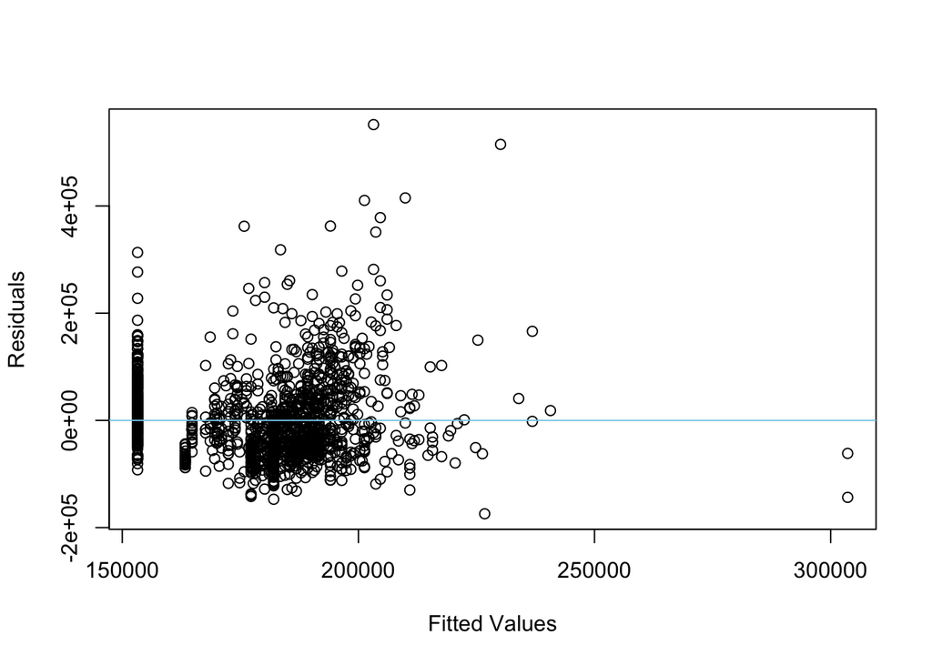

```r
# Residuals scatterplot
plot(train.lm$fitted.values, train.lm$residuals, xlab="Fitted Values", ylab="Residuals")
abline(h=0, col="skyblue")
```

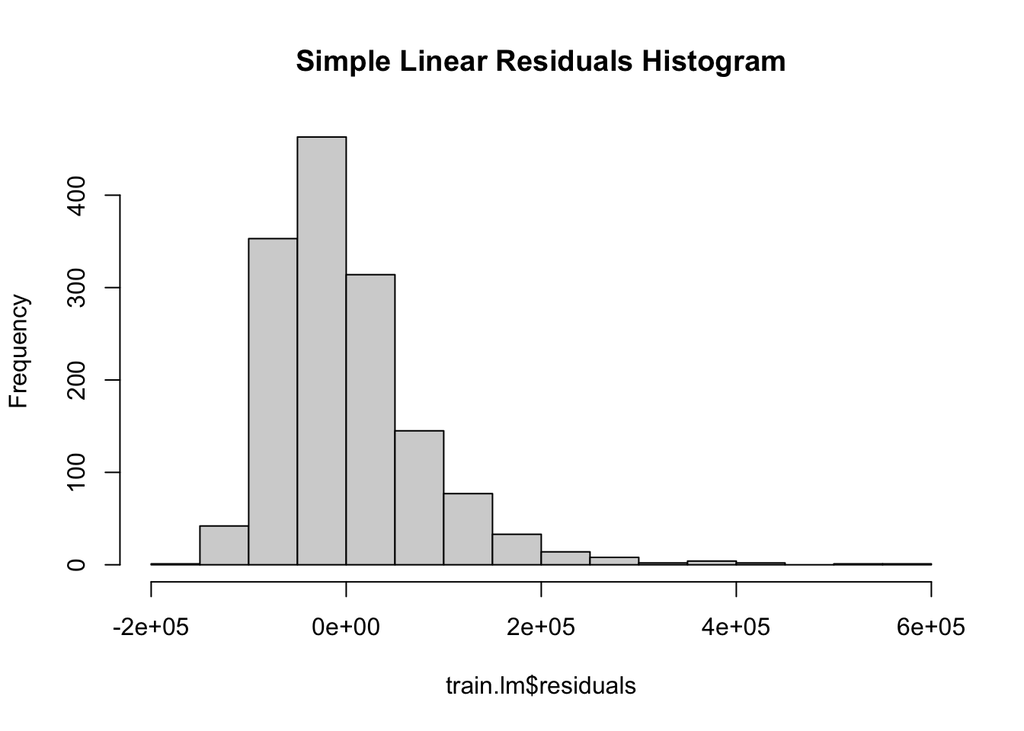

```r
# Residuals Histogram
hist(train.lm$residuals, main="Simple Linear Residuals Histogram")
```

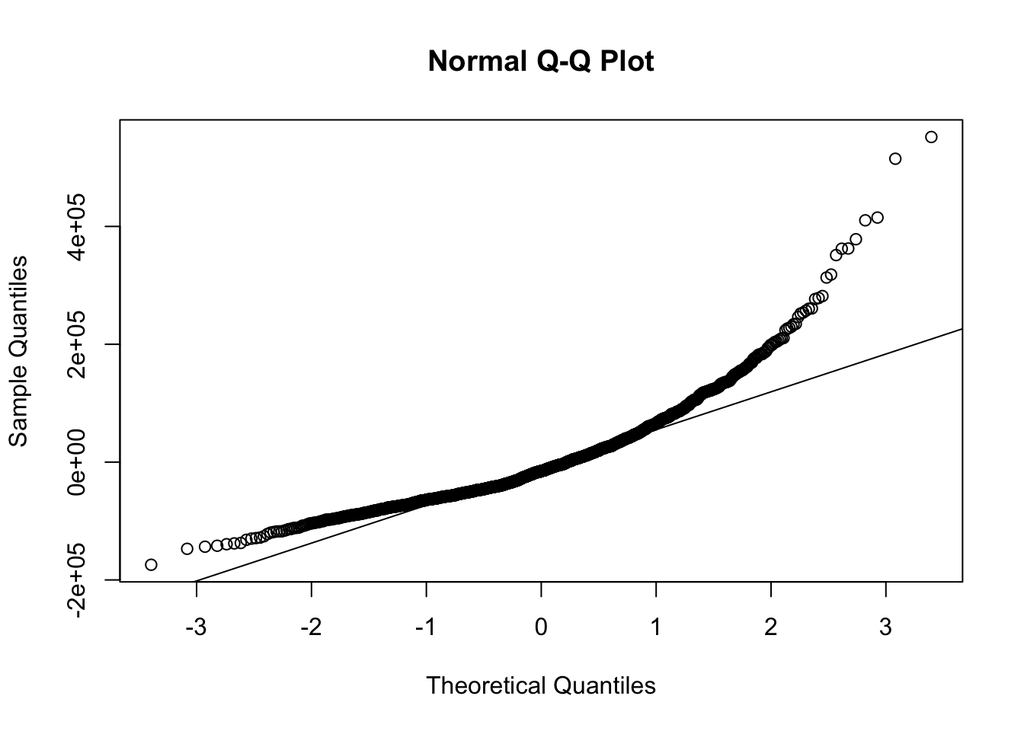

```r
# QQ Plot
qqnorm(train.lm$residuals)
qqline(train.lm$residuals)
```

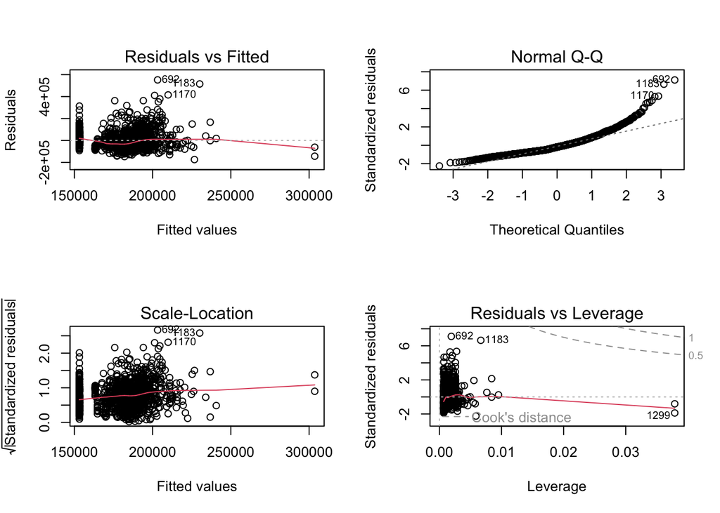

```r
# Plot
par(mfrow=c(2,2))
plot(train.lm)
```

**Multiple Linear Regression**

```r
# Multiple regression model
train.lm2 <- lm(saleprice ~ lotfrontage + lotarea, data = houses)

# Check summary of our multiple-regression model
summary(train.lm2)
```

```
##
## Call:
## lm(formula = saleprice ~ lotfrontage + lotarea, data = houses)
##
## Residuals:
##     Min      1Q  Median      3Q     Max
## -244639  -49347  -14962   31267  532920
##
## Coefficients:
##              Estimate Std. Error t value Pr(>|t|)
## (Intercept) 1.360e+05  4.206e+03  32.326  < 2e-16 ***
## lotfrontage 4.238e+02  5.714e+01   7.417 2.03e-13 ***
## lotarea     1.952e+00  1.984e-01   9.835  < 2e-16 ***
## ---
## Signif. codes:  0 '***' 0.001 '**' 0.01 '*' 0.05 '.' 0.1 ' ' 1
##
## Residual standard error: 75270 on 1457 degrees of freedom
## Multiple R-squared:  0.1035, Adjusted R-squared:  0.1022
## F-statistic: 84.07 on 2 and 1457 DF,  p-value: < 2.2e-16
```

```r
# Read test.csv
test_data <- read.csv("https://raw.githubusercontent.com/waheeb123/Data-605/main/Final%20Project/house-prices-advanced-regression-techniques/test.csv")

# Summary
summary(test_data)
```

```
##        Id         MSSubClass       MSZoning          LotFrontage
##  Min.   :1461   Min.   : 20.00   Length:1459        Min.   : 21.00
##  1st Qu.:1826   1st Qu.: 20.00   Class :character   1st Qu.: 58.00
##  Median :2190   Median : 50.00   Mode  :character   Median : 67.00
##  Mean   :2190   Mean   : 57.38                      Mean   : 68.58
##  3rd Qu.:2554   3rd Qu.: 70.00                      3rd Qu.: 80.00
##  Max.   :2919   Max.   :190.00                      Max.   :200.00
##                                                     NA's   :227
##     LotArea         Street             Alley             LotShape
##  Min.   : 1470   Length:1459        Length:1459        Length:1459
##  1st Qu.: 7391   Class :character   Class :character   Class :character
##  Median : 9399   Mode  :character   Mode  :character   Mode  :character
##  Mean   : 9819
##  3rd Qu.:11518
##  Max.   :56600
##
##  LandContour         Utilities          LotConfig          LandSlope
##  Length:1459        Length:1459        Length:1459        Length:1459
##  Class :character   Class :character   Class :character   Class :character
##  Mode  :character   Mode  :character   Mode  :character   Mode  :character
##
##
##
##
##  Neighborhood        Condition1         Condition2          BldgType
##  Length:1459        Length:1459        Length:1459        Length:1459
##  Class :character   Class :character   Class :character   Class :character
##  Mode  :character   Mode  :character   Mode  :character   Mode  :character
##
##
##
##
##   HouseStyle         OverallQual      OverallCond      YearBuilt
##  Length:1459        Min.   : 1.000   Min.   :1.000   Min.   :1879
##  Class :character   1st Qu.: 5.000   1st Qu.:5.000   1st Qu.:1953
##  Mode  :character   Median : 6.000   Median :5.000   Median :1973
##                     Mean   : 6.079   Mean   :5.554   Mean   :1971
##                     3rd Qu.: 7.000   3rd Qu.:6.000   3rd Qu.:2001
##                     Max.   :10.000   Max.   :9.000   Max.   :2010
##
```

[output cut: 105 more lines]

```
##  Length:1459        Length:1459        Length:1459        Min.   :    0.00
##  Class :character   Class :character   Class :character   1st Qu.:    0.00
##  Mode  :character   Mode  :character   Mode  :character   Median :    0.00
##                                                           Mean   :   58.17
##                                                           3rd Qu.:    0.00
##                                                           Max.   :17000.00
##
##      MoSold           YrSold       SaleType         SaleCondition
##  Min.   : 1.000   Min.   :2006   Length:1459        Length:1459
##  1st Qu.: 4.000   1st Qu.:2007   Class :character   Class :character
##  Median : 6.000   Median :2008   Mode  :character   Mode  :character
##  Mean   : 6.104   Mean   :2008
##  3rd Qu.: 8.000   3rd Qu.:2009
##  Max.   :12.000   Max.   :2010
##
```

```r
# Check for nulls/missing data
anyNA(test_data)
```

```
## [1] TRUE
```

```r
# How many missing values?
sum(is.na(test_data))
```

```
## [1] 7000
```

```r
# 7000 missing values


# Missing values from each column
Missing_values2 <- colSums(is.na(test_data))
Missing_values2[Missing_values2>0]
```

```
##     MSZoning  LotFrontage        Alley    Utilities  Exterior1st  Exterior2nd
##            4          227         1352            2            1            1
##   MasVnrType   MasVnrArea     BsmtQual     BsmtCond BsmtExposure BsmtFinType1
##           16           15           44           45           44           42
##   BsmtFinSF1 BsmtFinType2   BsmtFinSF2    BsmtUnfSF  TotalBsmtSF BsmtFullBath
##            1           42            1            1            1            2
## BsmtHalfBath  KitchenQual   Functional  FireplaceQu   GarageType  GarageYrBlt
##            2            1            2          730           76           78
## GarageFinish   GarageCars   GarageArea   GarageQual   GarageCond       PoolQC
##           78            1            1           78           78         1456
##        Fence  MiscFeature     SaleType
##         1169         1408            1
```

```r
# Let's replace the missing numeric records with the average value of each column
for(i in 1:ncol(test_data)){
  test_data[is.na(test_data[ ,i]), i] <- mean(test_data[ ,i], na.rm = TRUE)
}


# Now replace the missing values in the categorical variables (https://stackoverflow.com/questions/36377813/impute-most-frequent-categorical-value-in-all-columns-in-data-frame)
i2 <- !sapply(test_data, is.numeric)

# Most common value
Mode <- function(x) {
      ux <- sort(unique(x))
      ux[which.max(tabulate(match(x, ux)))]
}

# Replace the NAs in character columns with the most freq
test_data[i2] <- lapply(test_data[i2], function(x)
              replace(x, is.na(x), Mode(x[!is.na(x)])))

# Check to see if any values are missing/NA
sum(is.na(test_data))
```

```
## [1] 0
```

```r
# Create new dataframe of ID's and predicted SalePrice for Kaggle Submission
Kaggle <- test_data[, c('Id', 'LotFrontage')]

# Export new dataframe to csv
write.csv(Kaggle, "605final.csv", row.names = FALSE)
```

[Waheeb Algabri](https://www.kaggle.com/learnernone)